# Prevod teploty: Celsius na Fahrenheit

Autor

Nazar Fomin

Publikované

13. apríla 2026

# 1 Úvod

Meranie teploty patrí medzi základné fyzikálne merania v prírodných vedách, technike aj každodennom živote. V histórii vzniklo viacero teplotných stupníc, pričom dve z nich - Celziova a Fahrenheitova - sa dodnes používajú súbežne (Halliday et al. 2013). Kým väčšina sveta (vrátane Slovenska) používa stupeň Celzia (°C), Spojené štáty americké a niekoľko ďalších krajín stále pracujú s Fahrenheitmi (°F). Vzájomný prevod je preto prakticky dôležitou úlohou.

Cieľom tohto dokumentu je odvodiť a demonštrovať vzorec na prevod teploty z Celziových stupňov na Fahrenheitove stupne, zostaviť tabuľku prevodových hodnôt a graficky znázorniť lineárnu závislosť medzi obidvoma stupnicami.

# 2 Teplotné stupnice a prevodový vzorec

## 2.1 História teplotných stupníc

Celziova stupnica bola definovaná tak, aby bod tuhnutia vody bol 0 °C a bod varu vody 100 °C (pri atmosferickom tlaku). Fahrenheitova stupnica je staršia: Daniel Gabriel Fahrenheit stanovil 0 °F ako teplotu zmesi ľadu, vody a chloridu amónneho a 96 °F ako teplotu ľudského tela. Na tejto stupnici voda tuhne pri 32 °F a vrie pri 212 °F.

## 2.2 Matematický vzorec

Z lineárnej závislosti oboch stupníc vyplýva prevodový vzorec. Rozsah 100 celziových stupňov (0 °C - 100 °C) zodpovedá rozsahu 180 fahrenheitových stupňov (32 °F - 212 °F), odkiaľ dostaneme pomer $\frac{9}{5}$. Po zohľadnení posunutia nulového bodu platí:

$$F = \frac{9}{5} \cdot C + 32
\tag{1}$$

kde $C$ je teplota v stupňoch Celzia a $F$ je teplota v stupňoch Fahrenheita. Vzorec Rovnica 1 je lineárnou funkciou s smernicou $\frac{9}{5} = 1{,}8$ a posunom $+32$.

# 3 Tabuľka prevodových hodnôt

Pomocou vzorca Rovnica 1 vypočítame hodnoty pre vybraný súbor teplôt bežne sa vyskytujúcich v praxi (Tabuľka 1).

Tabuľka 1: Prevod vybraných teplôt z Celziových na Fahrenheitové stupne

```
|   Teplota (°C) |   Teplota (°F) |
|---------------:|---------------:|
|            -20 |           -4   |
|            -10 |           14   |
|              0 |           32   |
|             10 |           50   |
|             20 |           68   |
|             37 |           98.6 |
|            100 |          212   |
```

Z tabuľky Tabuľka 1 je zrejmé, že teplota ľudského tela (37 °C) zodpovedá 98,6 °F, a že bod mrazu (0 °C) leží na 32 °F - hodnota charakteristická pre Fahrenheitovu stupnicu.

# 4 Grafická závislosť

Pre lepšiu ilustráciu lineárnej povahy prevodového vzorca Rovnica 1 znázorňuje Obrázok 1 závislosť teploty vo Fahrenheitoch od teploty v Celziách v rozsahu od −30 °C do 110 °C.

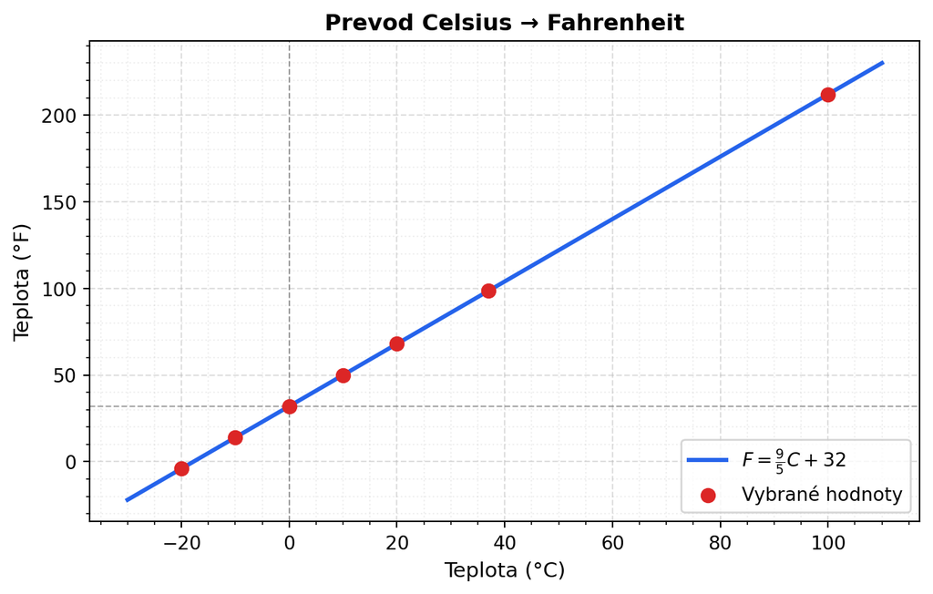

Obrázok 1: Závislosť teploty vo Fahrenheitoch (°F) od teploty v Celziách (°C)

Graf (Obrázok 1) potvrdzuje lineárny charakter závislosti. Červené body zodpovedajú hodnotám z tabuľky Tabuľka 1. Prerušované čiary označujú bod mrazu (0 °C = 32 °F).

# 5 Záver

V tomto dokumente sme odvodili a overili vzorec na prevod teploty z Celziových na Fahrenheitové stupne (pozri Rovnica 1). Tabuľka (Tabuľka 1) uvádza prakticky dôležité hodnoty vrátane bodu mrazu, telesnej teploty a bodu varu. Graf (Obrázok 1) graficky dokumentuje lineárnu závislosť oboch stupníc.

Pochopenie vzájomného vzťahu teplotných stupníc má praktický význam nielen v každodennom živote, ale aj v medzinárodnej vedeckej komunikácii, kde sa stretneme s obidvoma konvenciami.

# Zoznam použitej literatúry

HALLIDAY, David, Robert RESNICK a Jearl WALKER, 2013. *Fyzika*. Brno: VUTIUM. ISBN 978-80-214-4123-1.